# Time Series Forecasting

## Introduction

#### Dataset:

- Contains data of sales and profit of a Furniture company.
- The time period is year 2014 to 2017.
- Number of observations: 9994
- Number of variables: 21
- Variables to focus: Category and Order Date.
- Link to download dataset: **https://community.tableau.com/docs/DOC-1236**

#### Libraries Used:

1. pandas
2. numpy
3. matplotlib
4. seaborn
5. Prophet

#### Modules Used:

1. warnings
2. from pylab import rcParams
3. from fbprophet import prophet

#### Approach:

- Fetched raw dataset.
- Retrieved 'Furniture' and 'Office Supplies' cateogies.
- Retrieved corresponding sales.
- Created Sales forecasting model for 'Furniture' and 'Office Supplies' categories.
- Retrieved profit for the respective categories.
- Created Profit forecasting model.
- Validated models using k-fold-cross-validation.

#### Libraries to be installed before running the notebook:

1. **msgpack**
   - *anaconda*: conda install -c anaconda msgpack-python
1. **fbprophet and pystan**
   - *anaconda*: conda install -c conda-forge fbprophet

#### Time Alias used:

- Link: **http://pandas.pydata.org/pandas-docs/stable/timeseries.html#offset-aliases**

#### Prophet Documentation:

- Link: **https://facebook.github.io/prophet/docs/installation.html**
- Link: **https://github.com/facebook/prophet**

## 1. Data Load

#### 1.1 Importing required libraries

```python
import warnings
#import itertools
import numpy as np
import matplotlib.pyplot as plt
import pandas as pd
import statsmodels.api as sm
import matplotlib
import seaborn as sns
```

#### 1.2 Importing dataset

```python
df = pd.read_excel('E:\\ML\\Time Series\\Superstore.xls')
```

#### 1.3 Inspecting total number of observations (rows) and variables (columns)

```python
df.shape
```

```
(9994, 21)
```

- We have 9,994 rows and 21 columns.

#### 1.4 Printing unique categories

```python
df['Category'].unique()
```

```
array(['Furniture', 'Office Supplies', 'Technology'], dtype=object)
```

#### 1.5 Retrieving 'Furniture' category

```python
furniture = df.loc[df['Category'] == 'Furniture']
```

#### 1.6 Populating 5 observations

```python
furniture.head()
```

|  | Row ID | Order ID | Order Date | Ship Date | Ship Mode | Customer ID | Customer Name | Segment | Country | City | ... | Postal Code | Region | Product ID | Category | Sub-Category | Product Name | Sales | Quantity | Discount | Profit |
| --- | --- | --- | --- | --- | --- | --- | --- | --- | --- | --- | --- | --- | --- | --- | --- | --- | --- | --- | --- | --- | --- |
| 0 | 1 | CA-2016-152156 | 2016-11-08 | 2016-11-11 | Second Class | CG-12520 | Claire Gute | Consumer | United States | Henderson | ... | 42420 | South | FUR-BO-10001798 | Furniture | Bookcases | Bush Somerset Collection Bookcase | 261.9600 | 2 | 0.00 | 41.9136 |
| 1 | 2 | CA-2016-152156 | 2016-11-08 | 2016-11-11 | Second Class | CG-12520 | Claire Gute | Consumer | United States | Henderson | ... | 42420 | South | FUR-CH-10000454 | Furniture | Chairs | Hon Deluxe Fabric Upholstered Stacking Chairs,... | 731.9400 | 3 | 0.00 | 219.5820 |
| 3 | 4 | US-2015-108966 | 2015-10-11 | 2015-10-18 | Standard Class | SO-20335 | Sean O'Donnell | Consumer | United States | Fort Lauderdale | ... | 33311 | South | FUR-TA-10000577 | Furniture | Tables | Bretford CR4500 Series Slim Rectangular Table | 957.5775 | 5 | 0.45 | -383.0310 |
| 5 | 6 | CA-2014-115812 | 2014-06-09 | 2014-06-14 | Standard Class | BH-11710 | Brosina Hoffman | Consumer | United States | Los Angeles | ... | 90032 | West | FUR-FU-10001487 | Furniture | Furnishings | Eldon Expressions Wood and Plastic Desk Access... | 48.8600 | 7 | 0.00 | 14.1694 |
| 10 | 11 | CA-2014-115812 | 2014-06-09 | 2014-06-14 | Standard Class | BH-11710 | Brosina Hoffman | Consumer | United States | Los Angeles | ... | 90032 | West | FUR-TA-10001539 | Furniture | Tables | Chromcraft Rectangular Conference Tables | 1706.1840 | 9 | 0.20 | 85.3092 |

5 rows × 21 columns

#### 1.7 Inspecting minimum and maximum order date

```python
furniture['Order Date'].min(), furniture['Order Date'].max()
```

```
(Timestamp('2014-01-06 00:00:00'), Timestamp('2017-12-30 00:00:00'))
```

#### 1.8 Setting index of order date

```python
fur = furniture.set_index('Order Date')
fur.index
```

```
DatetimeIndex(['2016-11-08', '2016-11-08', '2015-10-11', '2014-06-09',
               '2014-06-09', '2017-07-16', '2015-09-25', '2015-09-17',
               '2015-09-17', '2016-12-08',
               ...
               '2015-11-13', '2016-06-03', '2016-12-12', '2017-06-01',
               '2015-12-14', '2015-03-19', '2016-12-05', '2015-09-06',
               '2014-01-21', '2017-02-26'],
              dtype='datetime64[ns]', name='Order Date', length=2121, freq=None)
```

#### 1.9 Checking mean of Sales in the year 2017

```python
y = fur['Sales'].resample('MS').mean()
```

```python
y['2017':]
```

```
Order Date
2017-01-01    248.501333
2017-02-01    264.089900
2017-03-01    286.669600
2017-04-01    206.044502
2017-05-01    319.953928
2017-06-01    372.717386
2017-07-01    227.173500
2017-08-01    395.945487
2017-09-01    349.737422
2017-10-01    308.226313
2017-11-01    374.310253
2017-12-01    296.296857
Freq: MS, Name: Sales, dtype: float64
```

#### 1.20 Plotting trend of furniture sales

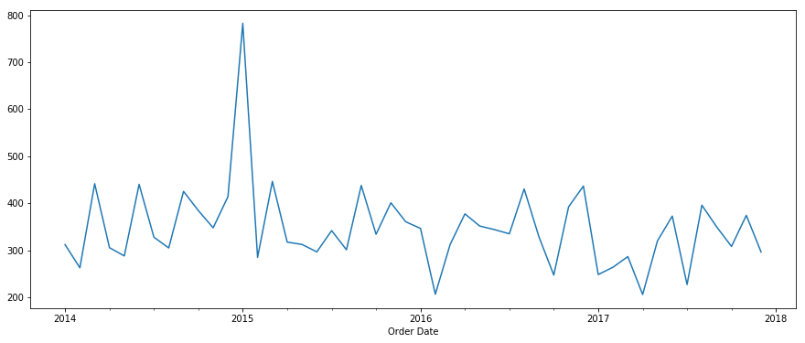

```python
y.plot(figsize=(15, 6))
plt.show()
```

#### 1.21 Plotting series

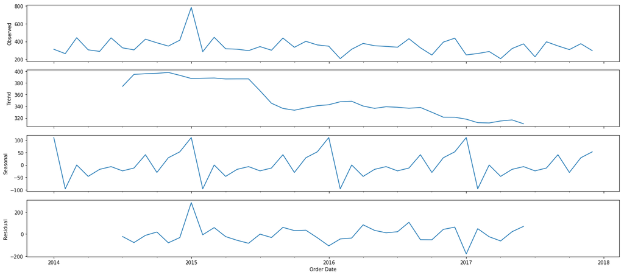

```python
from pylab import rcParams
rcParams['figure.figsize'] = 18, 8

decomposition = sm.tsa.seasonal_decompose(y, model='additive')
fig = decomposition.plot()
plt.show()
```

#### 1.22 Retrieving Office supplies category and checking observation and variable count of both furniture and office categories

```python
office = df.loc[df['Category'] == 'Office Supplies']
furniture.shape, office.shape
```

```
((2121, 21), (6026, 21))
```

## 2. Data preprocessing

#### 2.1 Selecting only required variables

```python
warnings.simplefilter("ignore")

cols = ['Row ID', 'Order ID', 'Ship Date', 'Ship Mode', 'Customer ID', 'Customer Name', 'Segment', 'Country', 'City',
        'State', 'Postal Code', 'Region', 'Product ID', 'Category', 'Sub-Category', 'Product Name', 'Quantity', 'Discount',
        'Profit']
furniture.drop(cols, axis=1, inplace=True)
office.drop(cols, axis=1, inplace=True)

furniture = furniture.sort_values('Order Date')
office = office.sort_values('Order Date')
```

- We have selected only 'Order Date' and 'Sales' variables.

#### 2.2 Populating 5 observations of furniture and office supplies dataframes

```python
furniture.head()
```

|  | Order Date | Sales |
| --- | --- | --- |
| 7474 | 2014-01-06 | 2573.820 |
| 7660 | 2014-01-07 | 76.728 |
| 866 | 2014-01-10 | 51.940 |
| 716 | 2014-01-11 | 9.940 |
| 2978 | 2014-01-13 | 545.940 |

```python
office.head()
```

|  | Order Date | Sales |
| --- | --- | --- |
| 7980 | 2014-01-03 | 16.448 |
| 740 | 2014-01-04 | 272.736 |
| 739 | 2014-01-04 | 11.784 |
| 741 | 2014-01-04 | 3.540 |
| 1759 | 2014-01-05 | 19.536 |

#### 2.2 Inspecting data types of variables

```python
furniture.dtypes
```

```
Order Date    datetime64[ns]
Sales                float64
dtype: object
```

```python
office.dtypes
```

```
Order Date    datetime64[ns]
Sales                float64
dtype: object
```

#### 2.3 Renaming Date variable as 'ds' and Sales variable as 'y'

```python
furniture = furniture.rename(columns={'Order Date': 'ds', 'Sales': 'y'})
office = office.rename(columns={'Order Date': 'ds', 'Sales': 'y'})
```

- Prophet library follows particular naming convention.

#### 2.4 Populating 5 observations of furniture and office supplies after renaming

```python
furniture.head()
```

|  | ds | y |
| --- | --- | --- |
| 7474 | 2014-01-06 | 2573.820 |
| 7660 | 2014-01-07 | 76.728 |
| 866 | 2014-01-10 | 51.940 |
| 716 | 2014-01-11 | 9.940 |
| 2978 | 2014-01-13 | 545.940 |

```python
office.head()
```

|  | ds | y |
| --- | --- | --- |
| 7980 | 2014-01-03 | 16.448 |
| 740 | 2014-01-04 | 272.736 |
| 739 | 2014-01-04 | 11.784 |
| 741 | 2014-01-04 | 3.540 |
| 1759 | 2014-01-05 | 19.536 |

## 3. Model Creation: Sales

#### 3.1 Fitting model on furniture

```python
from fbprophet import Prophet
warnings.simplefilter("ignore")

furniture_model = Prophet(interval_width=0.95,daily_seasonality=True)
furniture_model.fit(furniture)
```

```
<fbprophet.forecaster.Prophet at 0x21b4e5a1ba8>
```

#### 3.2 Fitting model on office

```python
warnings.simplefilter("ignore")

office_model = Prophet(interval_width=0.95,daily_seasonality=True)
office_model.fit(office)
```

```
<fbprophet.forecaster.Prophet at 0x21b4e5a1d68>
```

#### 3.3 Forecasting furniture sales for 3 years

```python
furniture_forecast = furniture_model.make_future_dataframe(periods=36, freq='MS')
furniture_forecast = furniture_model.predict(furniture_forecast)
```

#### 3.4 Forecasting office supplies sales for 3 years

```python
office_forecast = office_model.make_future_dataframe(periods=36, freq='MS')
office_forecast = office_model.predict(office_forecast)
```

#### 3.5 Plotting furniture sales

```
Text(0.5,1,'Furniture Sales')
```

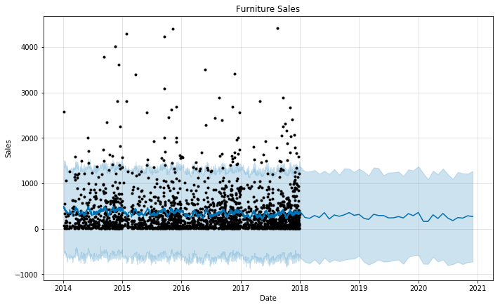

```python
plt.figure(figsize=(18, 6))
furniture_model.plot(furniture_forecast, xlabel = 'Date', ylabel = 'Sales')
plt.title('Furniture Sales')
```

- Black dots are the actual values.

#### 3.6 Plotting office supplies sales

```
Text(0.5,1,'Office Supplies Sales')
```

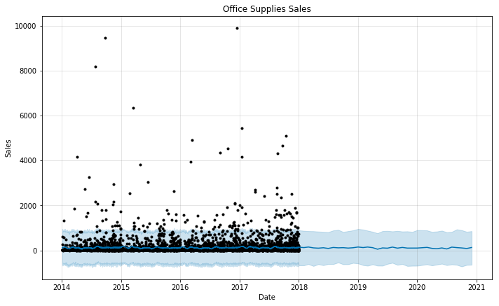

```python
plt.figure(figsize=(18, 6))
office_model.plot(office_forecast, xlabel = 'Date', ylabel = 'Sales')
plt.title('Office Supplies Sales')
```

#### 3.7 Furniture forecast values

- **'yhat'** is the forecasted sales.

```python
furniture_forecast.head()
```

|  | ds | trend | yhat_lower | yhat_upper | trend_lower | trend_upper | additive_terms | additive_terms_lower | additive_terms_upper | daily | ... | weekly | weekly_lower | weekly_upper | yearly | yearly_lower | yearly_upper | multiplicative_terms | multiplicative_terms_lower | multiplicative_terms_upper | yhat |
| --- | --- | --- | --- | --- | --- | --- | --- | --- | --- | --- | --- | --- | --- | --- | --- | --- | --- | --- | --- | --- | --- |
| 0 | 2014-01-06 | 2140.868194 | -521.758049 | 1513.260417 | 2140.868194 | 2140.868194 | -1647.000353 | -1647.000353 | -1647.000353 | -1726.091847 | ... | 26.153176 | 26.153176 | 26.153176 | 52.938319 | 52.938319 | 52.938319 | 0.0 | 0.0 | 0.0 | 493.867841 |
| 1 | 2014-01-07 | 2140.559034 | -530.206804 | 1442.389020 | 2140.559034 | 2140.559034 | -1697.034145 | -1697.034145 | -1697.034145 | -1726.091847 | ... | -21.343828 | -21.343828 | -21.343828 | 50.401530 | 50.401530 | 50.401530 | 0.0 | 0.0 | 0.0 | 443.524889 |
| 2 | 2014-01-10 | 2139.631555 | -524.093791 | 1355.187172 | 2139.631555 | 2139.631555 | -1683.914276 | -1683.914276 | -1683.914276 | -1726.091847 | ... | 3.808991 | 3.808991 | 3.808991 | 38.368580 | 38.368580 | 38.368580 | 0.0 | 0.0 | 0.0 | 455.717279 |
| 3 | 2014-01-11 | 2139.322395 | -576.847371 | 1350.869467 | 2139.322395 | 2139.322395 | -1729.645322 | -1729.645322 | -1729.645322 | -1726.091847 | ... | -36.518686 | -36.518686 | -36.518686 | 32.965211 | 32.965211 | 32.965211 | 0.0 | 0.0 | 0.0 | 409.677073 |
| 4 | 2014-01-13 | 2138.704075 | -483.583398 | 1492.419214 | 2138.704075 | 2138.704075 | -1679.510619 | -1679.510619 | -1679.510619 | -1726.091847 | ... | 26.153176 | 26.153176 | 26.153176 | 20.428052 | 20.428052 | 20.428052 | 0.0 | 0.0 | 0.0 | 459.193456 |

5 rows × 22 columns

#### 3.8 Office Supplies forecast values

```python
office_forecast.head()
```

|  | ds | trend | yhat_lower | yhat_upper | trend_lower | trend_upper | additive_terms | additive_terms_lower | additive_terms_upper | daily | ... | weekly | weekly_lower | weekly_upper | yearly | yearly_lower | yearly_upper | multiplicative_terms | multiplicative_terms_lower | multiplicative_terms_upper | yhat |
| --- | --- | --- | --- | --- | --- | --- | --- | --- | --- | --- | --- | --- | --- | --- | --- | --- | --- | --- | --- | --- | --- |
| 0 | 2014-01-03 | 31.473025 | -606.085593 | 950.024966 | 31.473025 | 31.473025 | 83.898457 | 83.898457 | 83.898457 | 60.107746 | ... | 4.806727 | 4.806727 | 4.806727 | 18.983984 | 18.983984 | 18.983984 | 0.0 | 0.0 | 0.0 | 115.371482 |
| 1 | 2014-01-04 | 31.649115 | -672.400033 | 857.901062 | 31.649115 | 31.649115 | 82.242518 | 82.242518 | 82.242518 | 60.107746 | ... | 0.776002 | 0.776002 | 0.776002 | 21.358769 | 21.358769 | 21.358769 | 0.0 | 0.0 | 0.0 | 113.891633 |
| 2 | 2014-01-04 | 31.649115 | -604.906815 | 828.097966 | 31.649115 | 31.649115 | 82.242518 | 82.242518 | 82.242518 | 60.107746 | ... | 0.776002 | 0.776002 | 0.776002 | 21.358769 | 21.358769 | 21.358769 | 0.0 | 0.0 | 0.0 | 113.891633 |
| 3 | 2014-01-04 | 31.649115 | -601.020028 | 891.679062 | 31.649115 | 31.649115 | 82.242518 | 82.242518 | 82.242518 | 60.107746 | ... | 0.776002 | 0.776002 | 0.776002 | 21.358769 | 21.358769 | 21.358769 | 0.0 | 0.0 | 0.0 | 113.891633 |
| 4 | 2014-01-05 | 31.825204 | -603.542687 | 829.861979 | 31.825204 | 31.825204 | 74.728359 | 74.728359 | 74.728359 | 60.107746 | ... | -9.213712 | -9.213712 | -9.213712 | 23.834324 | 23.834324 | 23.834324 | 0.0 | 0.0 | 0.0 | 106.553563 |

5 rows × 22 columns

#### 3.9 Merging furniture and office forecast to compare

```python
furniture_names = ['furniture_%s' % column for column in furniture_forecast.columns]
office_names = ['office_%s' % column for column in office_forecast.columns]
```

```python
furniture_names
```

```
['furniture_ds',
 'furniture_trend',
 'furniture_yhat_lower',
 'furniture_yhat_upper',
 'furniture_trend_lower',
 'furniture_trend_upper',
 'furniture_additive_terms',
 'furniture_additive_terms_lower',
 'furniture_additive_terms_upper',
 'furniture_daily',
 'furniture_daily_lower',
 'furniture_daily_upper',
 'furniture_weekly',
 'furniture_weekly_lower',
 'furniture_weekly_upper',
 'furniture_yearly',
 'furniture_yearly_lower',
 'furniture_yearly_upper',
 'furniture_multiplicative_terms',
 'furniture_multiplicative_terms_lower',
 'furniture_multiplicative_terms_upper',
 'furniture_yhat']
```

```python
office_names
```

```
['office_ds',
 'office_trend',
 'office_yhat_lower',
 'office_yhat_upper',
 'office_trend_lower',
 'office_trend_upper',
 'office_additive_terms',
 'office_additive_terms_lower',
 'office_additive_terms_upper',
 'office_daily',
 'office_daily_lower',
 'office_daily_upper',
 'office_weekly',
 'office_weekly_lower',
 'office_weekly_upper',
 'office_yearly',
 'office_yearly_lower',
 'office_yearly_upper',
 'office_multiplicative_terms',
 'office_multiplicative_terms_lower',
 'office_multiplicative_terms_upper',
 'office_yhat']
```

```python
merge_furniture_forecast = furniture_forecast.copy()
merge_office_forecast = office_forecast.copy()
```

```python
merge_furniture_forecast.head()
```

|  | ds | trend | yhat_lower | yhat_upper | trend_lower | trend_upper | additive_terms | additive_terms_lower | additive_terms_upper | daily | ... | weekly | weekly_lower | weekly_upper | yearly | yearly_lower | yearly_upper | multiplicative_terms | multiplicative_terms_lower | multiplicative_terms_upper | yhat |
| --- | --- | --- | --- | --- | --- | --- | --- | --- | --- | --- | --- | --- | --- | --- | --- | --- | --- | --- | --- | --- | --- |
| 0 | 2014-01-06 | 2140.868194 | -521.758049 | 1513.260417 | 2140.868194 | 2140.868194 | -1647.000353 | -1647.000353 | -1647.000353 | -1726.091847 | ... | 26.153176 | 26.153176 | 26.153176 | 52.938319 | 52.938319 | 52.938319 | 0.0 | 0.0 | 0.0 | 493.867841 |
| 1 | 2014-01-07 | 2140.559034 | -530.206804 | 1442.389020 | 2140.559034 | 2140.559034 | -1697.034145 | -1697.034145 | -1697.034145 | -1726.091847 | ... | -21.343828 | -21.343828 | -21.343828 | 50.401530 | 50.401530 | 50.401530 | 0.0 | 0.0 | 0.0 | 443.524889 |
| 2 | 2014-01-10 | 2139.631555 | -524.093791 | 1355.187172 | 2139.631555 | 2139.631555 | -1683.914276 | -1683.914276 | -1683.914276 | -1726.091847 | ... | 3.808991 | 3.808991 | 3.808991 | 38.368580 | 38.368580 | 38.368580 | 0.0 | 0.0 | 0.0 | 455.717279 |
| 3 | 2014-01-11 | 2139.322395 | -576.847371 | 1350.869467 | 2139.322395 | 2139.322395 | -1729.645322 | -1729.645322 | -1729.645322 | -1726.091847 | ... | -36.518686 | -36.518686 | -36.518686 | 32.965211 | 32.965211 | 32.965211 | 0.0 | 0.0 | 0.0 | 409.677073 |
| 4 | 2014-01-13 | 2138.704075 | -483.583398 | 1492.419214 | 2138.704075 | 2138.704075 | -1679.510619 | -1679.510619 | -1679.510619 | -1726.091847 | ... | 26.153176 | 26.153176 | 26.153176 | 20.428052 | 20.428052 | 20.428052 | 0.0 | 0.0 | 0.0 | 459.193456 |

5 rows × 22 columns

```python
merge_furniture_forecast.columns = furniture_names
```

```python
merge_furniture_forecast.head()
```

|  | furniture_ds | furniture_trend | furniture_yhat_lower | furniture_yhat_upper | furniture_trend_lower | furniture_trend_upper | furniture_additive_terms | furniture_additive_terms_lower | furniture_additive_terms_upper | furniture_daily | ... | furniture_weekly | furniture_weekly_lower | furniture_weekly_upper | furniture_yearly | furniture_yearly_lower | furniture_yearly_upper | furniture_multiplicative_terms | furniture_multiplicative_terms_lower | furniture_multiplicative_terms_upper | furniture_yhat |
| --- | --- | --- | --- | --- | --- | --- | --- | --- | --- | --- | --- | --- | --- | --- | --- | --- | --- | --- | --- | --- | --- |
| 0 | 2014-01-06 | 2140.868194 | -521.758049 | 1513.260417 | 2140.868194 | 2140.868194 | -1647.000353 | -1647.000353 | -1647.000353 | -1726.091847 | ... | 26.153176 | 26.153176 | 26.153176 | 52.938319 | 52.938319 | 52.938319 | 0.0 | 0.0 | 0.0 | 493.867841 |
| 1 | 2014-01-07 | 2140.559034 | -530.206804 | 1442.389020 | 2140.559034 | 2140.559034 | -1697.034145 | -1697.034145 | -1697.034145 | -1726.091847 | ... | -21.343828 | -21.343828 | -21.343828 | 50.401530 | 50.401530 | 50.401530 | 0.0 | 0.0 | 0.0 | 443.524889 |
| 2 | 2014-01-10 | 2139.631555 | -524.093791 | 1355.187172 | 2139.631555 | 2139.631555 | -1683.914276 | -1683.914276 | -1683.914276 | -1726.091847 | ... | 3.808991 | 3.808991 | 3.808991 | 38.368580 | 38.368580 | 38.368580 | 0.0 | 0.0 | 0.0 | 455.717279 |
| 3 | 2014-01-11 | 2139.322395 | -576.847371 | 1350.869467 | 2139.322395 | 2139.322395 | -1729.645322 | -1729.645322 | -1729.645322 | -1726.091847 | ... | -36.518686 | -36.518686 | -36.518686 | 32.965211 | 32.965211 | 32.965211 | 0.0 | 0.0 | 0.0 | 409.677073 |
| 4 | 2014-01-13 | 2138.704075 | -483.583398 | 1492.419214 | 2138.704075 | 2138.704075 | -1679.510619 | -1679.510619 | -1679.510619 | -1726.091847 | ... | 26.153176 | 26.153176 | 26.153176 | 20.428052 | 20.428052 | 20.428052 | 0.0 | 0.0 | 0.0 | 459.193456 |

5 rows × 22 columns

```python
merge_office_forecast.columns = office_names
```

```python
forecast = pd.merge(merge_furniture_forecast, merge_office_forecast,
                    how = 'inner',
                    left_on = 'furniture_ds',
                    right_on = 'office_ds')
```

```python
forecast.head()
```

|  | furniture_ds | furniture_trend | furniture_yhat_lower | furniture_yhat_upper | furniture_trend_lower | furniture_trend_upper | furniture_additive_terms | furniture_additive_terms_lower | furniture_additive_terms_upper | furniture_daily | ... | office_weekly | office_weekly_lower | office_weekly_upper | office_yearly | office_yearly_lower | office_yearly_upper | office_multiplicative_terms | office_multiplicative_terms_lower | office_multiplicative_terms_upper | office_yhat |
| --- | --- | --- | --- | --- | --- | --- | --- | --- | --- | --- | --- | --- | --- | --- | --- | --- | --- | --- | --- | --- | --- |
| 0 | 2014-01-06 | 2140.868194 | -521.758049 | 1513.260417 | 2140.868194 | 2140.868194 | -1647.000353 | -1647.000353 | -1647.000353 | -1726.091847 | ... | 5.182225 | 5.182225 | 5.182225 | 26.384355 | 26.384355 | 26.384355 | 0.0 | 0.0 | 0.0 | 123.675619 |
| 1 | 2014-01-06 | 2140.868194 | -521.758049 | 1513.260417 | 2140.868194 | 2140.868194 | -1647.000353 | -1647.000353 | -1647.000353 | -1726.091847 | ... | 5.182225 | 5.182225 | 5.182225 | 26.384355 | 26.384355 | 26.384355 | 0.0 | 0.0 | 0.0 | 123.675619 |
| 2 | 2014-01-06 | 2140.868194 | -521.758049 | 1513.260417 | 2140.868194 | 2140.868194 | -1647.000353 | -1647.000353 | -1647.000353 | -1726.091847 | ... | 5.182225 | 5.182225 | 5.182225 | 26.384355 | 26.384355 | 26.384355 | 0.0 | 0.0 | 0.0 | 123.675619 |
| 3 | 2014-01-06 | 2140.868194 | -521.758049 | 1513.260417 | 2140.868194 | 2140.868194 | -1647.000353 | -1647.000353 | -1647.000353 | -1726.091847 | ... | 5.182225 | 5.182225 | 5.182225 | 26.384355 | 26.384355 | 26.384355 | 0.0 | 0.0 | 0.0 | 123.675619 |
| 4 | 2014-01-06 | 2140.868194 | -521.758049 | 1513.260417 | 2140.868194 | 2140.868194 | -1647.000353 | -1647.000353 | -1647.000353 | -1726.091847 | ... | 5.182225 | 5.182225 | 5.182225 | 26.384355 | 26.384355 | 26.384355 | 0.0 | 0.0 | 0.0 | 123.675619 |

5 rows × 44 columns

```python
forecast = forecast.rename(columns={'furniture_ds': 'Date'}).drop('office_ds', axis=1)
forecast.head()
```

|  | Date | furniture_trend | furniture_yhat_lower | furniture_yhat_upper | furniture_trend_lower | furniture_trend_upper | furniture_additive_terms | furniture_additive_terms_lower | furniture_additive_terms_upper | furniture_daily | ... | office_weekly | office_weekly_lower | office_weekly_upper | office_yearly | office_yearly_lower | office_yearly_upper | office_multiplicative_terms | office_multiplicative_terms_lower | office_multiplicative_terms_upper | office_yhat |
| --- | --- | --- | --- | --- | --- | --- | --- | --- | --- | --- | --- | --- | --- | --- | --- | --- | --- | --- | --- | --- | --- |
| 0 | 2014-01-06 | 2140.868194 | -521.758049 | 1513.260417 | 2140.868194 | 2140.868194 | -1647.000353 | -1647.000353 | -1647.000353 | -1726.091847 | ... | 5.182225 | 5.182225 | 5.182225 | 26.384355 | 26.384355 | 26.384355 | 0.0 | 0.0 | 0.0 | 123.675619 |
| 1 | 2014-01-06 | 2140.868194 | -521.758049 | 1513.260417 | 2140.868194 | 2140.868194 | -1647.000353 | -1647.000353 | -1647.000353 | -1726.091847 | ... | 5.182225 | 5.182225 | 5.182225 | 26.384355 | 26.384355 | 26.384355 | 0.0 | 0.0 | 0.0 | 123.675619 |
| 2 | 2014-01-06 | 2140.868194 | -521.758049 | 1513.260417 | 2140.868194 | 2140.868194 | -1647.000353 | -1647.000353 | -1647.000353 | -1726.091847 | ... | 5.182225 | 5.182225 | 5.182225 | 26.384355 | 26.384355 | 26.384355 | 0.0 | 0.0 | 0.0 | 123.675619 |
| 3 | 2014-01-06 | 2140.868194 | -521.758049 | 1513.260417 | 2140.868194 | 2140.868194 | -1647.000353 | -1647.000353 | -1647.000353 | -1726.091847 | ... | 5.182225 | 5.182225 | 5.182225 | 26.384355 | 26.384355 | 26.384355 | 0.0 | 0.0 | 0.0 | 123.675619 |
| 4 | 2014-01-06 | 2140.868194 | -521.758049 | 1513.260417 | 2140.868194 | 2140.868194 | -1647.000353 | -1647.000353 | -1647.000353 | -1726.091847 | ... | 5.182225 | 5.182225 | 5.182225 | 26.384355 | 26.384355 | 26.384355 | 0.0 | 0.0 | 0.0 | 123.675619 |

5 rows × 43 columns

#### 3.10 Plotting furniture and office supplies sales trend

```
Text(0.5,1,'Furniture vs. Office Supplies Sales Trend')
```

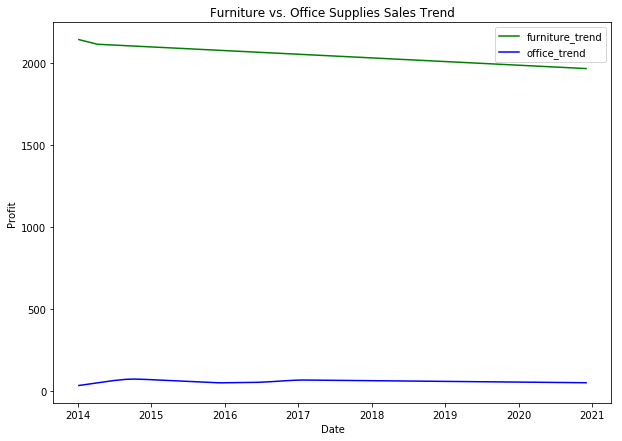

```python
plt.figure(figsize=(10, 7))
plt.plot(forecast['Date'], forecast['furniture_trend'], 'g-')
plt.plot(forecast['Date'], forecast['office_trend'], 'b-')
plt.legend()
plt.xlabel('Date'); plt.ylabel('Profit')
plt.title('Furniture vs. Office Supplies Sales Trend')
```

#### 3.11 Plotting furniture and office supplies forecasted values

```
Text(0.5,1,'Furniture vs. Office Supplies Estimate')
```

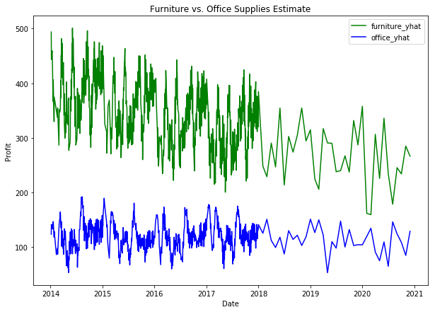

```python
plt.figure(figsize=(10, 7))
plt.plot(forecast['Date'], forecast['furniture_yhat'], 'g-')
plt.plot(forecast['Date'], forecast['office_yhat'], 'b-')
plt.legend()
plt.xlabel('Date')
plt.ylabel('Profit')
plt.title('Furniture vs. Office Supplies Estimate')
```

#### 3.12 Plotting furniture components

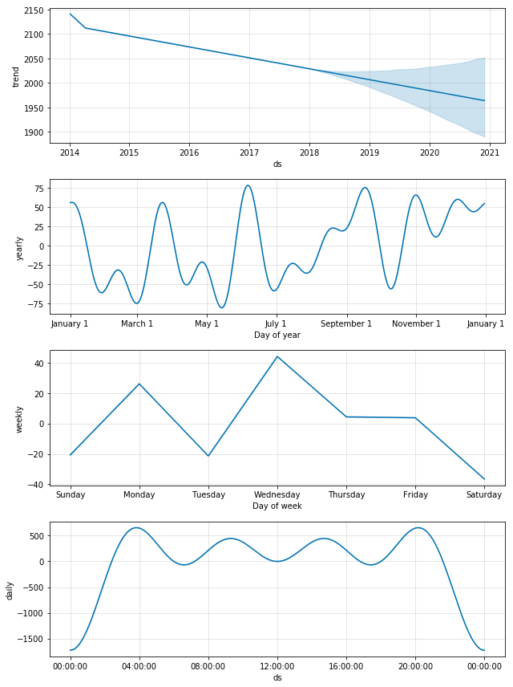

```python
furniture_model.plot_components(furniture_forecast);
```

#### 3.13 Plotting office supplies components

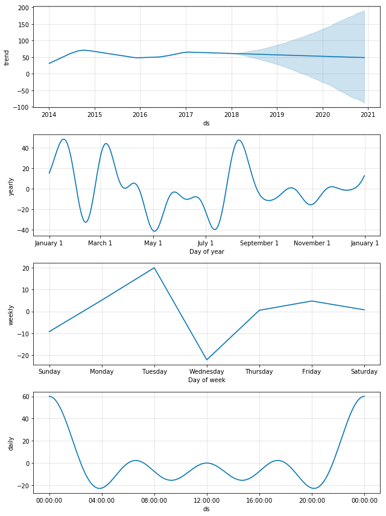

```python
office_model.plot_components(office_forecast);
```

#### 3.14 Cross Validating furniture model only

```python
from fbprophet.diagnostics import cross_validation
warnings.simplefilter("ignore")

df_cv = cross_validation(furniture_model, initial='365 days', period='180 days', horizon = '365 days')
df_cv.head()
```

```
INFO:fbprophet.diagnostics:Making 5 forecasts with cutoffs between 2015-01-10 00:00:00 and 2016-12-30 00:00:00
```

|  | ds | yhat | yhat_lower | yhat_upper | y | cutoff |
| --- | --- | --- | --- | --- | --- | --- |
| 0 | 2015-01-13 | 22.653035 | -955.454962 | 976.061590 | 77.600 | 2015-01-10 |
| 1 | 2015-01-13 | 22.653035 | -970.187611 | 950.085001 | 464.850 | 2015-01-10 |
| 2 | 2015-01-17 | -92.206684 | -1056.714817 | 881.106127 | 254.744 | 2015-01-10 |
| 3 | 2015-01-19 | 10.341500 | -981.943466 | 970.106710 | 199.304 | 2015-01-10 |
| 4 | 2015-01-19 | 10.341500 | -1002.275025 | 933.932657 | 102.438 | 2015-01-10 |

#### 3.15 Metrics of furniture

```python
from fbprophet.diagnostics import performance_metrics
df_p = performance_metrics(df_cv)
df_p.head()
```

|  | horizon | mse | rmse | mae | mape | coverage |
| --- | --- | --- | --- | --- | --- | --- |
| 34 | 62 days | 275969.478377 | 525.327972 | 322.252391 | 6.244707 | 0.964413 |
| 36 | 62 days | 275655.833721 | 525.029365 | 321.212154 | 6.203224 | 0.964413 |
| 2176 | 62 days | 272485.395409 | 522.001337 | 318.366034 | 6.201827 | 0.964413 |
| 1598 | 62 days | 272178.064376 | 521.706876 | 317.460203 | 6.160986 | 0.964413 |
| 1003 | 63 days | 271546.647006 | 521.101379 | 316.529979 | 6.095028 | 0.964413 |

#### 3.16 Horizon vs Mape plot of furniture sales

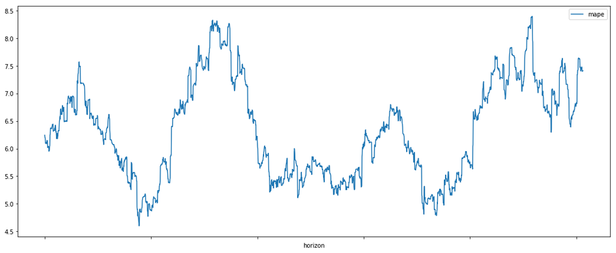

```python
df_p.plot(x='horizon',y='mape')
```

## 4. Model Creation: Profit

## 4.1. Data preprocessing

#### 4.1.1 Retrieving categories

```python
furniture = df.loc[df['Category'] == 'Furniture']
office = df.loc[df['Category'] == 'Office Supplies']
furniture.shape, office.shape
```

```
((2121, 21), (6026, 21))
```

#### 4.1.2 Selecting only required variables

```python
warnings.simplefilter("ignore")

cols = ['Row ID', 'Order ID', 'Ship Date', 'Ship Mode', 'Customer ID', 'Customer Name', 'Segment', 'Country', 'City',
        'State', 'Postal Code', 'Region', 'Product ID', 'Category', 'Sub-Category', 'Product Name', 'Quantity', 'Discount',
        'Sales']
furniture.drop(cols, axis=1, inplace=True)
office.drop(cols, axis=1, inplace=True)

furniture = furniture.sort_values('Order Date')
office = office.sort_values('Order Date')
```

#### 4.1.3 Populating 5 observations of furniture and office supplies dataframes

```python
furniture.head()
```

|  | Order Date | Profit |
| --- | --- | --- |
| 7474 | 2014-01-06 | 746.4078 |
| 7660 | 2014-01-07 | -53.7096 |
| 866 | 2014-01-10 | 21.2954 |
| 716 | 2014-01-11 | 3.0814 |
| 2978 | 2014-01-13 | 87.3504 |

```python
office.head()
```

|  | Order Date | Profit |
| --- | --- | --- |
| 7980 | 2014-01-03 | 5.5512 |
| 740 | 2014-01-04 | -64.7748 |
| 739 | 2014-01-04 | 4.2717 |
| 741 | 2014-01-04 | -5.4870 |
| 1759 | 2014-01-05 | 4.8840 |

#### 4.1.4 Inspecting data types of variables

```python
furniture.dtypes
```

```
Order Date    datetime64[ns]
Profit               float64
dtype: object
```

```python
office.dtypes
```

```
Order Date    datetime64[ns]
Profit               float64
dtype: object
```

```python
furniture = furniture.rename(columns={'Order Date': 'ds', 'Profit': 'y'})
office = office.rename(columns={'Order Date': 'ds', 'Profit': 'y'})
```

- Prophet library follows particular naming convention.

#### 4.1.6 Populating 5 observations of furniture and office supplies after renaming

```python
furniture.head()
```

|  | ds | y |
| --- | --- | --- |
| 7474 | 2014-01-06 | 746.4078 |
| 7660 | 2014-01-07 | -53.7096 |
| 866 | 2014-01-10 | 21.2954 |
| 716 | 2014-01-11 | 3.0814 |
| 2978 | 2014-01-13 | 87.3504 |

```python
office.head()
```

|  | ds | y |
| --- | --- | --- |
| 7980 | 2014-01-03 | 5.5512 |
| 740 | 2014-01-04 | -64.7748 |
| 739 | 2014-01-04 | 4.2717 |
| 741 | 2014-01-04 | -5.4870 |
| 1759 | 2014-01-05 | 4.8840 |

## 4.2 Model Creation

#### 4.2.1 Fitting Model on furniture

```python
from fbprophet import Prophet
warnings.simplefilter("ignore")

furniture_model = Prophet(interval_width=0.95,daily_seasonality=True)
furniture_model.fit(furniture)
```

```
<fbprophet.forecaster.Prophet at 0x21b51bf2320>
```

#### 4.2.2 Fitting model on office

```python
warnings.simplefilter("ignore")
office_model = Prophet(interval_width=0.95,daily_seasonality=True)
office_model.fit(office)
```

```
<fbprophet.forecaster.Prophet at 0x21b57747128>
```

#### 4.2.3 Forecasting furniture sales for 3 years

```python
furniture_forecast = furniture_model.make_future_dataframe(periods=36, freq='MS')
furniture_forecast = furniture_model.predict(furniture_forecast)
```

#### 4.2.4 Forecasting office supplies sales for 3 years

```python
office_forecast = office_model.make_future_dataframe(periods=36, freq='MS')
office_forecast = office_model.predict(office_forecast)
```

```
Text(0.5,1,'Furniture Sales')
```

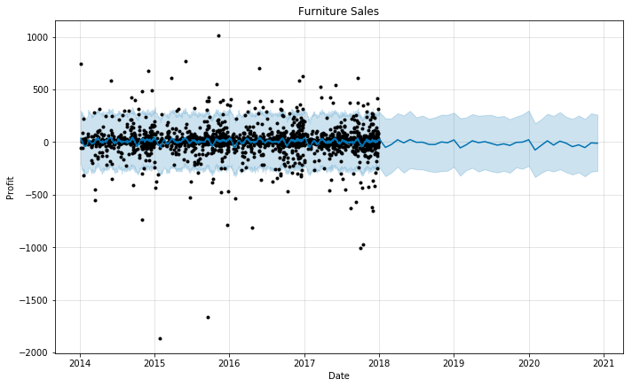

```python
plt.figure(figsize=(18, 6))
furniture_model.plot(furniture_forecast, xlabel = 'Date', ylabel = 'Profit')
plt.title('Furniture Sales')
```

- Black dots are the actual values.

```
Text(0.5,1,'Office Supplies Sales')
```

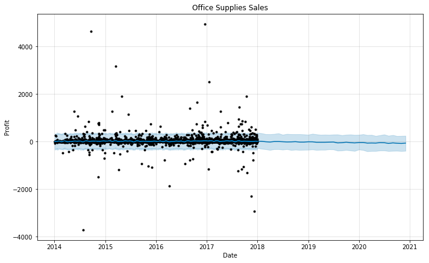

```python
plt.figure(figsize=(18, 6))
office_model.plot(office_forecast, xlabel = 'Date', ylabel = 'Profit')
plt.title('Office Supplies Sales')
```

#### 4.2.7 Furniture forecast values

- 'yhat' is the forecasted sales.

```python
furniture_forecast.head()
```

|  | ds | trend | yhat_lower | yhat_upper | trend_lower | trend_upper | additive_terms | additive_terms_lower | additive_terms_upper | daily | ... | weekly | weekly_lower | weekly_upper | yearly | yearly_lower | yearly_upper | multiplicative_terms | multiplicative_terms_lower | multiplicative_terms_upper | yhat |
| --- | --- | --- | --- | --- | --- | --- | --- | --- | --- | --- | --- | --- | --- | --- | --- | --- | --- | --- | --- | --- | --- |
| 0 | 2014-01-06 | 598.130005 | -215.815332 | 299.860310 | 598.130005 | 598.130005 | -562.454805 | -562.454805 | -562.454805 | -590.562963 | ... | 2.439432 | 2.439432 | 2.439432 | 25.668727 | 25.668727 | 25.668727 | 0.0 | 0.0 | 0.0 | 35.675201 |
| 1 | 2014-01-07 | 598.131678 | -211.260482 | 296.270881 | 598.131678 | 598.131678 | -565.357361 | -565.357361 | -565.357361 | -590.562963 | ... | 1.632872 | 1.632872 | 1.632872 | 23.572730 | 23.572730 | 23.572730 | 0.0 | 0.0 | 0.0 | 32.774317 |
| 2 | 2014-01-10 | 598.136697 | -248.424713 | 278.102231 | 598.136697 | 598.136697 | -577.901629 | -577.901629 | -577.901629 | -590.562963 | ... | -1.360528 | -1.360528 | -1.360528 | 14.021862 | 14.021862 | 14.021862 | 0.0 | 0.0 | 0.0 | 20.235067 |
| 3 | 2014-01-11 | 598.138369 | -267.468387 | 248.060827 | 598.138369 | 598.138369 | -592.435456 | -592.435456 | -592.435456 | -590.562963 | ... | -11.741949 | -11.741949 | -11.741949 | 9.869456 | 9.869456 | 9.869456 | 0.0 | 0.0 | 0.0 | 5.702914 |
| 4 | 2014-01-13 | 598.141715 | -246.739378 | 282.634780 | 598.141715 | 598.141715 | -587.665250 | -587.665250 | -587.665250 | -590.562963 | ... | 2.439432 | 2.439432 | 2.439432 | 0.458281 | 0.458281 | 0.458281 | 0.0 | 0.0 | 0.0 | 10.476465 |

5 rows × 22 columns

#### 4.2.8 Office Supplies forecast values

```python
office_forecast.head()
```

|  | ds | trend | yhat_lower | yhat_upper | trend_lower | trend_upper | additive_terms | additive_terms_lower | additive_terms_upper | daily | ... | weekly | weekly_lower | weekly_upper | yearly | yearly_lower | yearly_upper | multiplicative_terms | multiplicative_terms_lower | multiplicative_terms_upper | yhat |
| --- | --- | --- | --- | --- | --- | --- | --- | --- | --- | --- | --- | --- | --- | --- | --- | --- | --- | --- | --- | --- | --- |
| 0 | 2014-01-03 | 6.844487 | -325.857482 | 332.461129 | 6.844487 | 6.844487 | 3.235666 | 3.235666 | 3.235666 | 5.175226 | ... | -1.682374 | -1.682374 | -1.682374 | -0.257187 | -0.257187 | -0.257187 | 0.0 | 0.0 | 0.0 | 10.080153 |
| 1 | 2014-01-04 | 6.876491 | -326.007135 | 337.689598 | 6.876491 | 6.876491 | 1.245278 | 1.245278 | 1.245278 | 5.175226 | ... | -2.922857 | -2.922857 | -2.922857 | -1.007092 | -1.007092 | -1.007092 | 0.0 | 0.0 | 0.0 | 8.121769 |
| 2 | 2014-01-04 | 6.876491 | -326.888609 | 321.379857 | 6.876491 | 6.876491 | 1.245278 | 1.245278 | 1.245278 | 5.175226 | ... | -2.922857 | -2.922857 | -2.922857 | -1.007092 | -1.007092 | -1.007092 | 0.0 | 0.0 | 0.0 | 8.121769 |
| 3 | 2014-01-04 | 6.876491 | -326.352185 | 321.461529 | 6.876491 | 6.876491 | 1.245278 | 1.245278 | 1.245278 | 5.175226 | ... | -2.922857 | -2.922857 | -2.922857 | -1.007092 | -1.007092 | -1.007092 | 0.0 | 0.0 | 0.0 | 8.121769 |
| 4 | 2014-01-05 | 6.908494 | -308.652547 | 308.005104 | 6.908494 | 6.908494 | -5.884989 | -5.884989 | -5.884989 | 5.175226 | ... | -9.380013 | -9.380013 | -9.380013 | -1.680202 | -1.680202 | -1.680202 | 0.0 | 0.0 | 0.0 | 1.023506 |

5 rows × 22 columns

#### 4.2.9 Merging furniture and office forecast to compare

```python
furniture_names = ['furniture_%s' % column for column in furniture_forecast.columns]
office_names = ['office_%s' % column for column in office_forecast.columns]
```

```python
furniture_names
```

```
['furniture_ds',
 'furniture_trend',
 'furniture_yhat_lower',
 'furniture_yhat_upper',
 'furniture_trend_lower',
 'furniture_trend_upper',
 'furniture_additive_terms',
 'furniture_additive_terms_lower',
 'furniture_additive_terms_upper',
 'furniture_daily',
 'furniture_daily_lower',
 'furniture_daily_upper',
 'furniture_weekly',
 'furniture_weekly_lower',
 'furniture_weekly_upper',
 'furniture_yearly',
 'furniture_yearly_lower',
 'furniture_yearly_upper',
 'furniture_multiplicative_terms',
 'furniture_multiplicative_terms_lower',
 'furniture_multiplicative_terms_upper',
 'furniture_yhat']
```

```python
office_names
```

```
['office_ds',
 'office_trend',
 'office_yhat_lower',
 'office_yhat_upper',
 'office_trend_lower',
 'office_trend_upper',
 'office_additive_terms',
 'office_additive_terms_lower',
 'office_additive_terms_upper',
 'office_daily',
 'office_daily_lower',
 'office_daily_upper',
 'office_weekly',
 'office_weekly_lower',
 'office_weekly_upper',
 'office_yearly',
 'office_yearly_lower',
 'office_yearly_upper',
 'office_multiplicative_terms',
 'office_multiplicative_terms_lower',
 'office_multiplicative_terms_upper',
 'office_yhat']
```

```python
merge_furniture_forecast = furniture_forecast.copy()
merge_office_forecast = office_forecast.copy()
```

```python
merge_furniture_forecast.head()
```

|  | ds | trend | yhat_lower | yhat_upper | trend_lower | trend_upper | additive_terms | additive_terms_lower | additive_terms_upper | daily | ... | weekly | weekly_lower | weekly_upper | yearly | yearly_lower | yearly_upper | multiplicative_terms | multiplicative_terms_lower | multiplicative_terms_upper | yhat |
| --- | --- | --- | --- | --- | --- | --- | --- | --- | --- | --- | --- | --- | --- | --- | --- | --- | --- | --- | --- | --- | --- |
| 0 | 2014-01-06 | 598.130005 | -215.815332 | 299.860310 | 598.130005 | 598.130005 | -562.454805 | -562.454805 | -562.454805 | -590.562963 | ... | 2.439432 | 2.439432 | 2.439432 | 25.668727 | 25.668727 | 25.668727 | 0.0 | 0.0 | 0.0 | 35.675201 |
| 1 | 2014-01-07 | 598.131678 | -211.260482 | 296.270881 | 598.131678 | 598.131678 | -565.357361 | -565.357361 | -565.357361 | -590.562963 | ... | 1.632872 | 1.632872 | 1.632872 | 23.572730 | 23.572730 | 23.572730 | 0.0 | 0.0 | 0.0 | 32.774317 |
| 2 | 2014-01-10 | 598.136697 | -248.424713 | 278.102231 | 598.136697 | 598.136697 | -577.901629 | -577.901629 | -577.901629 | -590.562963 | ... | -1.360528 | -1.360528 | -1.360528 | 14.021862 | 14.021862 | 14.021862 | 0.0 | 0.0 | 0.0 | 20.235067 |
| 3 | 2014-01-11 | 598.138369 | -267.468387 | 248.060827 | 598.138369 | 598.138369 | -592.435456 | -592.435456 | -592.435456 | -590.562963 | ... | -11.741949 | -11.741949 | -11.741949 | 9.869456 | 9.869456 | 9.869456 | 0.0 | 0.0 | 0.0 | 5.702914 |
| 4 | 2014-01-13 | 598.141715 | -246.739378 | 282.634780 | 598.141715 | 598.141715 | -587.665250 | -587.665250 | -587.665250 | -590.562963 | ... | 2.439432 | 2.439432 | 2.439432 | 0.458281 | 0.458281 | 0.458281 | 0.0 | 0.0 | 0.0 | 10.476465 |

5 rows × 22 columns

```python
merge_furniture_forecast.columns = furniture_names
```

```python
merge_furniture_forecast.head()
```

|  | furniture_ds | furniture_trend | furniture_yhat_lower | furniture_yhat_upper | furniture_trend_lower | furniture_trend_upper | furniture_additive_terms | furniture_additive_terms_lower | furniture_additive_terms_upper | furniture_daily | ... | furniture_weekly | furniture_weekly_lower | furniture_weekly_upper | furniture_yearly | furniture_yearly_lower | furniture_yearly_upper | furniture_multiplicative_terms | furniture_multiplicative_terms_lower | furniture_multiplicative_terms_upper | furniture_yhat |
| --- | --- | --- | --- | --- | --- | --- | --- | --- | --- | --- | --- | --- | --- | --- | --- | --- | --- | --- | --- | --- | --- |
| 0 | 2014-01-06 | 598.130005 | -215.815332 | 299.860310 | 598.130005 | 598.130005 | -562.454805 | -562.454805 | -562.454805 | -590.562963 | ... | 2.439432 | 2.439432 | 2.439432 | 25.668727 | 25.668727 | 25.668727 | 0.0 | 0.0 | 0.0 | 35.675201 |
| 1 | 2014-01-07 | 598.131678 | -211.260482 | 296.270881 | 598.131678 | 598.131678 | -565.357361 | -565.357361 | -565.357361 | -590.562963 | ... | 1.632872 | 1.632872 | 1.632872 | 23.572730 | 23.572730 | 23.572730 | 0.0 | 0.0 | 0.0 | 32.774317 |
| 2 | 2014-01-10 | 598.136697 | -248.424713 | 278.102231 | 598.136697 | 598.136697 | -577.901629 | -577.901629 | -577.901629 | -590.562963 | ... | -1.360528 | -1.360528 | -1.360528 | 14.021862 | 14.021862 | 14.021862 | 0.0 | 0.0 | 0.0 | 20.235067 |
| 3 | 2014-01-11 | 598.138369 | -267.468387 | 248.060827 | 598.138369 | 598.138369 | -592.435456 | -592.435456 | -592.435456 | -590.562963 | ... | -11.741949 | -11.741949 | -11.741949 | 9.869456 | 9.869456 | 9.869456 | 0.0 | 0.0 | 0.0 | 5.702914 |
| 4 | 2014-01-13 | 598.141715 | -246.739378 | 282.634780 | 598.141715 | 598.141715 | -587.665250 | -587.665250 | -587.665250 | -590.562963 | ... | 2.439432 | 2.439432 | 2.439432 | 0.458281 | 0.458281 | 0.458281 | 0.0 | 0.0 | 0.0 | 10.476465 |

5 rows × 22 columns

```python
merge_office_forecast.columns = office_names
```

```python
forecast = pd.merge(merge_furniture_forecast, merge_office_forecast,
                    how = 'inner',
                    left_on = 'furniture_ds',
                    right_on = 'office_ds')
```

```python
forecast.head()
```

|  | furniture_ds | furniture_trend | furniture_yhat_lower | furniture_yhat_upper | furniture_trend_lower | furniture_trend_upper | furniture_additive_terms | furniture_additive_terms_lower | furniture_additive_terms_upper | furniture_daily | ... | office_weekly | office_weekly_lower | office_weekly_upper | office_yearly | office_yearly_lower | office_yearly_upper | office_multiplicative_terms | office_multiplicative_terms_lower | office_multiplicative_terms_upper | office_yhat |
| --- | --- | --- | --- | --- | --- | --- | --- | --- | --- | --- | --- | --- | --- | --- | --- | --- | --- | --- | --- | --- | --- |
| 0 | 2014-01-06 | 598.130005 | -215.815332 | 299.86031 | 598.130005 | 598.130005 | -562.454805 | -562.454805 | -562.454805 | -590.562963 | ... | 6.183384 | 6.183384 | 6.183384 | -2.256894 | -2.256894 | -2.256894 | 0.0 | 0.0 | 0.0 | 16.042214 |
| 1 | 2014-01-06 | 598.130005 | -215.815332 | 299.86031 | 598.130005 | 598.130005 | -562.454805 | -562.454805 | -562.454805 | -590.562963 | ... | 6.183384 | 6.183384 | 6.183384 | -2.256894 | -2.256894 | -2.256894 | 0.0 | 0.0 | 0.0 | 16.042214 |
| 2 | 2014-01-06 | 598.130005 | -215.815332 | 299.86031 | 598.130005 | 598.130005 | -562.454805 | -562.454805 | -562.454805 | -590.562963 | ... | 6.183384 | 6.183384 | 6.183384 | -2.256894 | -2.256894 | -2.256894 | 0.0 | 0.0 | 0.0 | 16.042214 |
| 3 | 2014-01-06 | 598.130005 | -215.815332 | 299.86031 | 598.130005 | 598.130005 | -562.454805 | -562.454805 | -562.454805 | -590.562963 | ... | 6.183384 | 6.183384 | 6.183384 | -2.256894 | -2.256894 | -2.256894 | 0.0 | 0.0 | 0.0 | 16.042214 |
| 4 | 2014-01-06 | 598.130005 | -215.815332 | 299.86031 | 598.130005 | 598.130005 | -562.454805 | -562.454805 | -562.454805 | -590.562963 | ... | 6.183384 | 6.183384 | 6.183384 | -2.256894 | -2.256894 | -2.256894 | 0.0 | 0.0 | 0.0 | 16.042214 |

5 rows × 44 columns

```python
forecast = forecast.rename(columns={'furniture_ds': 'Date'}).drop('office_ds', axis=1)
forecast.head()
```

|  | Date | furniture_trend | furniture_yhat_lower | furniture_yhat_upper | furniture_trend_lower | furniture_trend_upper | furniture_additive_terms | furniture_additive_terms_lower | furniture_additive_terms_upper | furniture_daily | ... | office_weekly | office_weekly_lower | office_weekly_upper | office_yearly | office_yearly_lower | office_yearly_upper | office_multiplicative_terms | office_multiplicative_terms_lower | office_multiplicative_terms_upper | office_yhat |
| --- | --- | --- | --- | --- | --- | --- | --- | --- | --- | --- | --- | --- | --- | --- | --- | --- | --- | --- | --- | --- | --- |
| 0 | 2014-01-06 | 598.130005 | -215.815332 | 299.86031 | 598.130005 | 598.130005 | -562.454805 | -562.454805 | -562.454805 | -590.562963 | ... | 6.183384 | 6.183384 | 6.183384 | -2.256894 | -2.256894 | -2.256894 | 0.0 | 0.0 | 0.0 | 16.042214 |
| 1 | 2014-01-06 | 598.130005 | -215.815332 | 299.86031 | 598.130005 | 598.130005 | -562.454805 | -562.454805 | -562.454805 | -590.562963 | ... | 6.183384 | 6.183384 | 6.183384 | -2.256894 | -2.256894 | -2.256894 | 0.0 | 0.0 | 0.0 | 16.042214 |
| 2 | 2014-01-06 | 598.130005 | -215.815332 | 299.86031 | 598.130005 | 598.130005 | -562.454805 | -562.454805 | -562.454805 | -590.562963 | ... | 6.183384 | 6.183384 | 6.183384 | -2.256894 | -2.256894 | -2.256894 | 0.0 | 0.0 | 0.0 | 16.042214 |
| 3 | 2014-01-06 | 598.130005 | -215.815332 | 299.86031 | 598.130005 | 598.130005 | -562.454805 | -562.454805 | -562.454805 | -590.562963 | ... | 6.183384 | 6.183384 | 6.183384 | -2.256894 | -2.256894 | -2.256894 | 0.0 | 0.0 | 0.0 | 16.042214 |
| 4 | 2014-01-06 | 598.130005 | -215.815332 | 299.86031 | 598.130005 | 598.130005 | -562.454805 | -562.454805 | -562.454805 | -590.562963 | ... | 6.183384 | 6.183384 | 6.183384 | -2.256894 | -2.256894 | -2.256894 | 0.0 | 0.0 | 0.0 | 16.042214 |

5 rows × 43 columns

```
Text(0.5,1,'Furniture vs. Office Supplies Profit Trend')
```

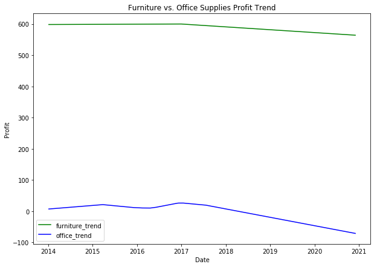

```python
plt.figure(figsize=(10, 7))
plt.plot(forecast['Date'], forecast['furniture_trend'], 'g-')
plt.plot(forecast['Date'], forecast['office_trend'], 'b-')
plt.legend()
plt.xlabel('Date'); plt.ylabel('Profit')
plt.title('Furniture vs. Office Supplies Profit Trend')
```

#### 4.2.12 Plotting furniture and office supplies forecasted values

```
Text(0.5,1,'Furniture vs. Office Supplies Estimate')
```

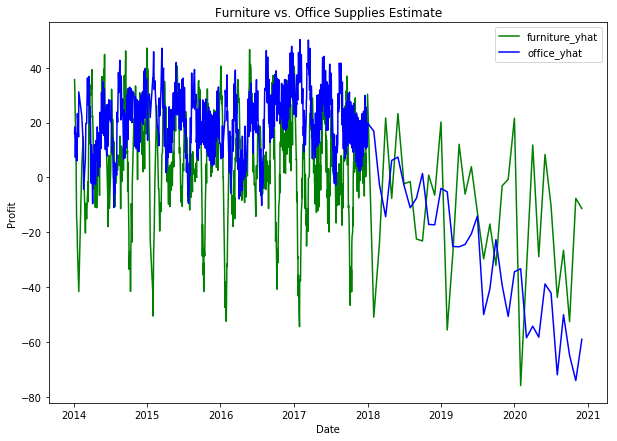

```python
plt.figure(figsize=(10, 7))
plt.plot(forecast['Date'], forecast['furniture_yhat'], 'g-')
plt.plot(forecast['Date'], forecast['office_yhat'], 'b-')
plt.legend()
plt.xlabel('Date')
plt.ylabel('Profit')
plt.title('Furniture vs. Office Supplies Estimate')
```

#### 4.2.13 Plotting furniture components

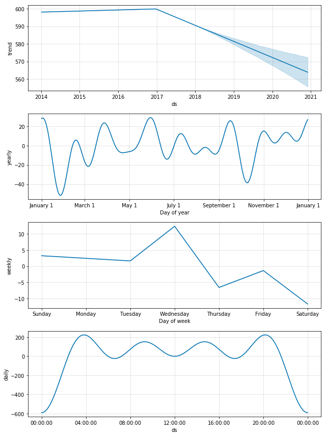

```python
furniture_model.plot_components(furniture_forecast);
```

#### 4.2.14 Plotting office supplies components

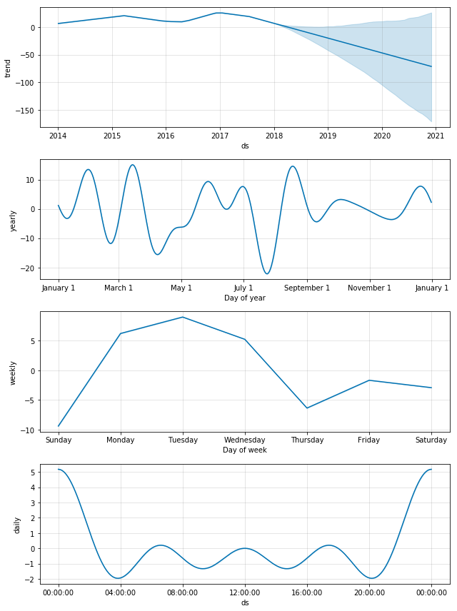

```python
office_model.plot_components(office_forecast);
```

#### 4.2.15 Cross Validating furniture model only

```python
from fbprophet.diagnostics import cross_validation
warnings.simplefilter("ignore")
df_cv = cross_validation(furniture_model, initial='365 days', period='180 days', horizon = '365 days')
df_cv.head()
```

```
INFO:fbprophet.diagnostics:Making 5 forecasts with cutoffs between 2015-01-10 00:00:00 and 2016-12-30 00:00:00
```

|  | ds | yhat | yhat_lower | yhat_upper | y | cutoff |
| --- | --- | --- | --- | --- | --- | --- |
| 0 | 2015-01-13 | -394.659570 | -635.468742 | -184.587244 | 38.0240 | 2015-01-10 |
| 1 | 2015-01-13 | -394.659570 | -628.971569 | -148.906524 | 92.9700 | 2015-01-10 |
| 2 | 2015-01-17 | -501.660935 | -728.308127 | -288.000015 | -312.0614 | 2015-01-10 |
| 3 | 2015-01-19 | -491.510358 | -704.817679 | -263.515587 | -8.5416 | 2015-01-10 |
| 4 | 2015-01-19 | -491.510358 | -712.012379 | -263.364053 | -13.1706 | 2015-01-10 |